# R Notebook

```
data("sleep")
head(sleep)
```

|  | extra | group | ID |
| --- | --- | --- | --- |
| 1 | 0.7 | 1 | 1 |
| 2 | -1.6 | 1 | 2 |
| 3 | -0.2 | 1 | 3 |
| 4 | -1.2 | 1 | 4 |
| 5 | -0.1 | 1 | 5 |
| 6 | 3.4 | 1 | 6 |

```
levels(sleep$group)
```

```
[1] "1" "2"
```

```
#boxplot for visuals of the data
boxplot(
          formula=extra~group,
          data=sleep,
          horizontal=TRUE,
          col= c("red","blue"),
          xlab = ("Change in sleep(hours)"),
          ylab = "Group"
          )
```

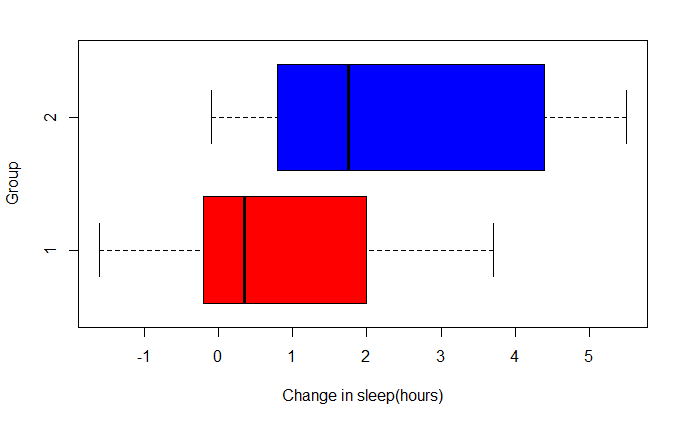

From the boxplot, there are no outliers in each group. The distribution of sleep pattern for group 2 is more right-skewed than those for group 1. Group 1 recorded more negative values than group 2. We will go ahead with our tests to establish statistical significance.

[output not shown]

CONCLUSION The population from which the data is drawn is normally distributed.

```
#test for equality of variance
var.test(sleep$extra[sleep$group == 1],
         sleep$extra[sleep$group == 2],
         alternative = "two.sided",
         conf.level = 0.95)
```

```
    F test to compare two variances

data:  sleep$extra[sleep$group == 1] and sleep$extra[sleep$group == 2]
F = 0.79834, num df = 9, denom df = 9, p-value = 0.7427
alternative hypothesis: true ratio of variances is not equal to 1
95 percent confidence interval:
 0.198297 3.214123
sample estimates:
ratio of variances
         0.7983426
```

Since the p-value is greater than the significancelevel alpha, we fail to reject the null hypothesis of the variance test.

CONCLUSION The variance of the population of both groups are equal.

```
#hypothesis test
t.test(formula=extra~group,
       data=sleep,
       var.equal=TRUE)
```

```
    Two Sample t-test

data:  extra by group
t = -1.8608, df = 18, p-value = 0.07919
alternative hypothesis: true difference in means between group 1 and group 2 is not equal to 0
95 percent confidence interval:
 -3.363874  0.203874
sample estimates:
mean in group 1 mean in group 2
           0.75            2.33
```

Since the p-value of the t-test is greater than the significance level alpha, we fail to reject the null hypothesis.

CONCLUSION The sample mean for group 2 is greater than the smaple mean of group 1. With 95% confidence, we say there is no statistically significant different in the average improvement of sleep patterns for both groups.